# Central Limit Theorem (CLT) - Simulation

June 17, 2017

## Central Limit Theorem Simulation

The CLT Simulation app is an educational tool that provides user to experience firsthand how the Central Limit Theorem works. The user can study the Central Limit Theorem with respect two distributions - the Exponential Distribution and Binomial Distribution.

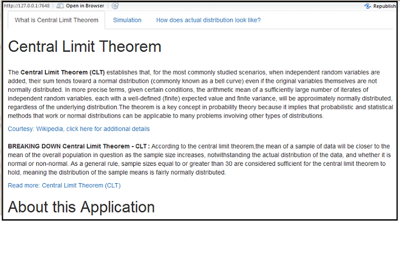

CLT Simulation App.

The Central Limit Theorem Simulation app consists of the following three tabs:

- What is Central Limit Theorem: This tab explains the Central Limit Theorem in brief and also explains how to use the application.
- Simulation: This tab provides user the facility to simulate central limit theorem using for different sample and simulation sizes.The user can see the distribution of means of samples in simulation.
- How does actual distribution look like?: This tab shows the user the actual distribution of data.

The app can be accessed at: https://saneshashank.shinyapps.io/cltsimulation/

Shown below is the Simulation tab, change the controls to change visualization.

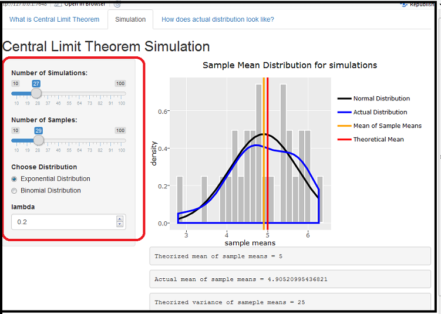

Simulation tab

Finally the - How does actual distribution look like ? tab shows the actual sample distribution.

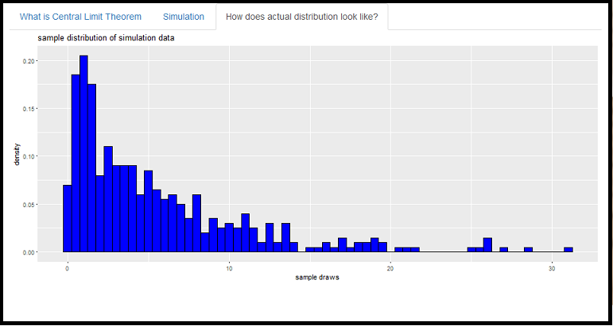

Thank You and enjoy the App!!